# Airports

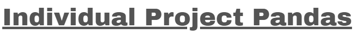

by [Gaspar Martinez S.](https://www.linkedin.com/in/gasparmartinezs/)

This project focuses on the manipulation and analysis of a dataset about airports, using the Python library called Pandas. The project involves a number of tasks including loading the data set as a data frame, removing unnecessary columns, identifying and handling null values, and grouping and analyzing the data.

The database has been extracted from the following website https://openflights.org/data.html.

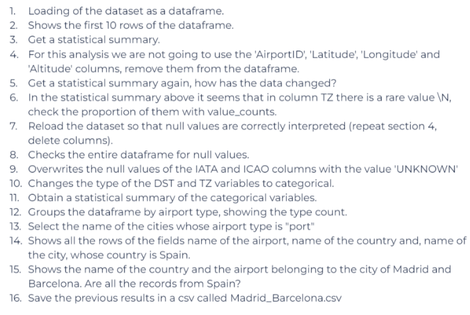

```python
import pandas as pd
import numpy as np
import matplotlib.pyplot as plt
```

## - Loading of the dataset as a dataframe.

With the pandas `read_csv` method we can load and read files with that extension. Since the given file does not contain a header we will have to clarify it with the `header=None` method. We are also going to clarify with the `encoding='utf-8'` method so that there are no symbology conflicts. In the second line of code with the `.columns` method we are going to create the header.

```python
df_airports = pd.read_csv('airports_extended.csv',header = None,  encoding='utf-8')
df_airports.columns = ['AirportID','Name','City','Country','IATA','ICAO','Latitude','Longitude','Altitude','Timezone','DST','Tz','Type','Source']
```

### - Shows the first 10 rows of the dataframe.

With the `.head()` method we can display the first 5 rows of the dataframe. If we want to see more than 5 rows, we must assign a value inside the parentheses.

```python
df_airports.head(10)
```

|  | AirportID | Name | City | Country | IATA | ICAO | Latitude | Longitude | Altitude | Timezone | DST | Tz | Type | Source |
| --- | --- | --- | --- | --- | --- | --- | --- | --- | --- | --- | --- | --- | --- | --- |
| 0 | 1 | Goroka Airport | Goroka | Papua New Guinea | GKA | AYGA | -6.081690 | 145.391998 | 5282 | 10 | U | Pacific/Port_Moresby | airport | OurAirports |
| 1 | 2 | Madang Airport | Madang | Papua New Guinea | MAG | AYMD | -5.207080 | 145.789001 | 20 | 10 | U | Pacific/Port_Moresby | airport | OurAirports |
| 2 | 3 | Mount Hagen Kagamuga Airport | Mount Hagen | Papua New Guinea | HGU | AYMH | -5.826790 | 144.296005 | 5388 | 10 | U | Pacific/Port_Moresby | airport | OurAirports |
| 3 | 4 | Nadzab Airport | Nadzab | Papua New Guinea | LAE | AYNZ | -6.569803 | 146.725977 | 239 | 10 | U | Pacific/Port_Moresby | airport | OurAirports |
| 4 | 5 | Port Moresby Jacksons International Airport | Port Moresby | Papua New Guinea | POM | AYPY | -9.443380 | 147.220001 | 146 | 10 | U | Pacific/Port_Moresby | airport | OurAirports |
| 5 | 6 | Wewak International Airport | Wewak | Papua New Guinea | WWK | AYWK | -3.583830 | 143.669006 | 19 | 10 | U | Pacific/Port_Moresby | airport | OurAirports |
| 6 | 7 | Narsarsuaq Airport | Narssarssuaq | Greenland | UAK | BGBW | 61.160500 | -45.425999 | 112 | -3 | E | America/Godthab | airport | OurAirports |
| 7 | 8 | Godthaab / Nuuk Airport | Godthaab | Greenland | GOH | BGGH | 64.190903 | -51.678101 | 283 | -3 | E | America/Godthab | airport | OurAirports |
| 8 | 9 | Kangerlussuaq Airport | Sondrestrom | Greenland | SFJ | BGSF | 67.012222 | -50.711603 | 165 | -3 | E | America/Godthab | airport | OurAirports |
| 9 | 10 | Thule Air Base | Thule | Greenland | THU | BGTL | 76.531197 | -68.703201 | 251 | -4 | E | America/Thule | airport | OurAirports |

### - Get a statistical summary.

To obtain the statistical summary of the `df`, use the `describe()` method. This will return a table containing various descriptive statistics for the numeric columns of the `df`, such as the mean, standard deviation, minimum and maximum value, and percentiles.

```python
df_airports.describe()
```

|  | AirportID | Latitude | Longitude | Altitude |
| --- | --- | --- | --- | --- |
| count | 12668.000000 | 12668.000000 | 12668.000000 | 12668.000000 |
| mean | 7311.584465 | 29.820510 | -1.041145 | 831.871093 |
| std | 4202.520098 | 26.923942 | 83.618663 | 1498.239733 |
| min | 1.000000 | -90.000000 | -179.876999 | -1266.000000 |
| 25% | 3349.750000 | 16.115875 | -77.294770 | 38.000000 |
| 50% | 7771.500000 | 38.341850 | 6.955411 | 232.500000 |
| 75% | 10943.250000 | 49.306042 | 47.835824 | 883.500000 |
| max | 14111.000000 | 90.000000 | 179.951004 | 14472.000000 |

```python
df_airports.info()
```

```
<class 'pandas.core.frame.DataFrame'>
RangeIndex: 12668 entries, 0 to 12667
Data columns (total 14 columns):
 #   Column     Non-Null Count  Dtype
---  ------     --------------  -----
 0   AirportID  12668 non-null  int64
 1   Name       12668 non-null  object
 2   City       12619 non-null  object
 3   Country    12668 non-null  object
 4   IATA       12668 non-null  object
 5   ICAO       12667 non-null  object
 6   Latitude   12668 non-null  float64
 7   Longitude  12668 non-null  float64
 8   Altitude   12668 non-null  int64
 9   Timezone   12668 non-null  object
 10  DST        12668 non-null  object
 11  Tz         12668 non-null  object
 12  Type       12668 non-null  object
 13  Source     12668 non-null  object
dtypes: float64(2), int64(2), object(10)
memory usage: 1.4+ MB
```

### - For this analysis we are not going to use the 'AirportID', 'Latitude', 'Longitude' and 'Altitude' columns, remove them from the dataframe.

To delete columns from a `df` you have to use the `.drop()` method, clarifying the axis. Keep in mind that `axis=0` is equivalent to rows and `axis=1` is equivalent to columns

```python
df_airports_v1 = df_airports.drop(['AirportID','Latitude','Longitude','Altitude'], axis = 1)
df_airports_v1
```

|  | Name | City | Country | IATA | ICAO | Timezone | DST | Tz | Type | Source |
| --- | --- | --- | --- | --- | --- | --- | --- | --- | --- | --- |
| 0 | Goroka Airport | Goroka | Papua New Guinea | GKA | AYGA | 10 | U | Pacific/Port_Moresby | airport | OurAirports |
| 1 | Madang Airport | Madang | Papua New Guinea | MAG | AYMD | 10 | U | Pacific/Port_Moresby | airport | OurAirports |
| 2 | Mount Hagen Kagamuga Airport | Mount Hagen | Papua New Guinea | HGU | AYMH | 10 | U | Pacific/Port_Moresby | airport | OurAirports |
| 3 | Nadzab Airport | Nadzab | Papua New Guinea | LAE | AYNZ | 10 | U | Pacific/Port_Moresby | airport | OurAirports |
| 4 | Port Moresby Jacksons International Airport | Port Moresby | Papua New Guinea | POM | AYPY | 10 | U | Pacific/Port_Moresby | airport | OurAirports |
| ... | ... | ... | ... | ... | ... | ... | ... | ... | ... | ... |
| 12663 | Ulan-Ude East Airport | Ulan Ude | Russia | \N | XIUW | \N | \N | \N | airport | OurAirports |
| 12664 | Krechevitsy Air Base | Novgorod | Russia | \N | ULLK | \N | \N | \N | airport | OurAirports |
| 12665 | Desierto de Atacama Airport | Copiapo | Chile | CPO | SCAT | \N | \N | \N | airport | OurAirports |
| 12666 | Melitopol Air Base | Melitopol | Ukraine | \N | UKDM | \N | \N | \N | airport | OurAirports |
| 12667 | Lincoln Train Station LNK | Lincoln | United States | \N | \N | -5 | A | \N | \N | \N |

12668 rows × 10 columns

### - Get a statistical summary again, how has the data changed?

```python
df_airports_v1.describe()
```

|  | Name | City | Country | IATA | ICAO | Timezone | DST | Tz | Type | Source |
| --- | --- | --- | --- | --- | --- | --- | --- | --- | --- | --- |
| count | 12668 | 12619 | 12668 | 12668 | 12667 | 12668 | 12668 | 12668 | 12668 | 12668 |
| unique | 12330 | 9673 | 241 | 6925 | 8161 | 42 | 8 | 312 | 5 | 4 |
| top | North Sea | New York | United States | \N | \N | 1 | E | \N | airport | OurAirports |
| freq | 21 | 50 | 2708 | 5744 | 4507 | 2706 | 3478 | 4282 | 8264 | 7698 |

### - In the statistical summary above it seems that in column TZ there is a rare value \N, check the proportion of them with value_counts.

To get the percentage of **'\N'** inside the **TZ** column we first create a variable containing all the values of **TZ** with the `value_counts` method. Then we use the method `.loc[]` to locate **'\N'**. Finally we divide it by the len of the **TZ** column.

```python
value_counts = df_airports_v1['Tz'].value_counts()
value_countsare_values = value_counts.loc['\\N']
proportion = value_countsare_values / len(df_airports_v1['Tz'])
print(f'The percentage of "/N" in the Tz column is: {proportion.round(2)} %')
```

[output not shown]

### - Reload the dataset so that null values are correctly interpreted (repeat section 4, delete columns).

Now that we know how many **'\N'** values we have what we are going to do is to reload the **Df** and repeat the previous steps. When we have completed we proceed to change the **'\N'** values to `NaN` values with the `replace` method and numpy's `np.nan` function.

```python
df_airports_v3 = pd.read_csv('airports_extended.csv', header= None, encoding='utf-8')
df_airports_v3.columns = ['AirportID','Name','City','Country','IATA','ICAO','Latitude','Longitude','Altitude','Timezone','DST','Tz','Type','Source']
df_airports_v3.drop(['AirportID','Latitude','Longitude','Altitude'], axis = 1,inplace=True)
df_airports_v3['Tz'].replace('\\N', np.nan, inplace=True)
df_airports_v3['IATA'].replace('\\N', np.nan, inplace=True)
df_airports_v3['ICAO'].replace('\\N', np.nan, inplace=True)
df_airports_v3['Timezone'].replace('\\N', np.nan, inplace=True)
df_airports_v3['Type'].replace('\\N', np.nan, inplace=True)
df_airports_v3['Source'].replace('\\N', np.nan, inplace=True)
df_airports_v3['DST'].replace('\\N', np.nan, inplace=True)
df_airports_v3
```

|  | Name | City | Country | IATA | ICAO | Timezone | DST | Tz | Type | Source |
| --- | --- | --- | --- | --- | --- | --- | --- | --- | --- | --- |
| 0 | Goroka Airport | Goroka | Papua New Guinea | GKA | AYGA | 10 | U | Pacific/Port_Moresby | airport | OurAirports |
| 1 | Madang Airport | Madang | Papua New Guinea | MAG | AYMD | 10 | U | Pacific/Port_Moresby | airport | OurAirports |
| 2 | Mount Hagen Kagamuga Airport | Mount Hagen | Papua New Guinea | HGU | AYMH | 10 | U | Pacific/Port_Moresby | airport | OurAirports |
| 3 | Nadzab Airport | Nadzab | Papua New Guinea | LAE | AYNZ | 10 | U | Pacific/Port_Moresby | airport | OurAirports |
| 4 | Port Moresby Jacksons International Airport | Port Moresby | Papua New Guinea | POM | AYPY | 10 | U | Pacific/Port_Moresby | airport | OurAirports |
| ... | ... | ... | ... | ... | ... | ... | ... | ... | ... | ... |
| 12663 | Ulan-Ude East Airport | Ulan Ude | Russia | NaN | XIUW | NaN | NaN | NaN | airport | OurAirports |
| 12664 | Krechevitsy Air Base | Novgorod | Russia | NaN | ULLK | NaN | NaN | NaN | airport | OurAirports |
| 12665 | Desierto de Atacama Airport | Copiapo | Chile | CPO | SCAT | NaN | NaN | NaN | airport | OurAirports |
| 12666 | Melitopol Air Base | Melitopol | Ukraine | NaN | UKDM | NaN | NaN | NaN | airport | OurAirports |
| 12667 | Lincoln Train Station LNK | Lincoln | United States | NaN | NaN | -5 | A | NaN | NaN | NaN |

12668 rows × 10 columns

### - Checks the entire dataframe for null values.

In order to sum all `NaN` values we have to use the following methods `.isna()` followed by `.sum()`. This will return the column names on the left and the number of `NaN` values on the right.

```python
df_airports_v3.isna().sum()
```

```
Name           0
City          49
Country        0
IATA        5744
ICAO        4508
Timezone     353
DST          353
Tz          4282
Type        1651
Source      1651
dtype: int64
```

### - Overwrites the null values of the IATA and ICAO columns with the value 'UNKNOWN'

In this exercise what we are going to do is to use the `.fillna` method to fill the space between `NaN` and replace them with **'UNKNOWN'**.

```python
df_airports_v3.IATA.fillna('UNKNOWN', inplace = True)
df_airports_v3.ICAO.fillna('UNKNOWN', inplace = True)
```

```python
df_airports_v3
```

|  | Name | City | Country | IATA | ICAO | Timezone | DST | Tz | Type | Source |
| --- | --- | --- | --- | --- | --- | --- | --- | --- | --- | --- |
| 0 | Goroka Airport | Goroka | Papua New Guinea | GKA | AYGA | 10 | U | Pacific/Port_Moresby | airport | OurAirports |
| 1 | Madang Airport | Madang | Papua New Guinea | MAG | AYMD | 10 | U | Pacific/Port_Moresby | airport | OurAirports |
| 2 | Mount Hagen Kagamuga Airport | Mount Hagen | Papua New Guinea | HGU | AYMH | 10 | U | Pacific/Port_Moresby | airport | OurAirports |
| 3 | Nadzab Airport | Nadzab | Papua New Guinea | LAE | AYNZ | 10 | U | Pacific/Port_Moresby | airport | OurAirports |
| 4 | Port Moresby Jacksons International Airport | Port Moresby | Papua New Guinea | POM | AYPY | 10 | U | Pacific/Port_Moresby | airport | OurAirports |
| ... | ... | ... | ... | ... | ... | ... | ... | ... | ... | ... |
| 12663 | Ulan-Ude East Airport | Ulan Ude | Russia | UNKNOWN | XIUW | NaN | NaN | NaN | airport | OurAirports |
| 12664 | Krechevitsy Air Base | Novgorod | Russia | UNKNOWN | ULLK | NaN | NaN | NaN | airport | OurAirports |
| 12665 | Desierto de Atacama Airport | Copiapo | Chile | CPO | SCAT | NaN | NaN | NaN | airport | OurAirports |
| 12666 | Melitopol Air Base | Melitopol | Ukraine | UNKNOWN | UKDM | NaN | NaN | NaN | airport | OurAirports |
| 12667 | Lincoln Train Station LNK | Lincoln | United States | UNKNOWN | UNKNOWN | -5 | A | NaN | NaN | NaN |

12668 rows × 10 columns

### - Changes the type of the DST and TZ variables to categorical.

To change the variable type to categorical it is necessary to use the `pd.Categorical` pandas method. This is used to convert numeric or text values into categories that can be used for analysis.

```python
df_airports_v3['DST'] = pd.Categorical(df_airports_v3['DST'])
df_airports_v3['Tz'] = pd.Categorical(df_airports_v3['Tz'])
```

```python
df_airports_v3
```

|  | Name | City | Country | IATA | ICAO | Timezone | DST | Tz | Type | Source |
| --- | --- | --- | --- | --- | --- | --- | --- | --- | --- | --- |
| 0 | Goroka Airport | Goroka | Papua New Guinea | GKA | AYGA | 10 | U | Pacific/Port_Moresby | airport | OurAirports |
| 1 | Madang Airport | Madang | Papua New Guinea | MAG | AYMD | 10 | U | Pacific/Port_Moresby | airport | OurAirports |
| 2 | Mount Hagen Kagamuga Airport | Mount Hagen | Papua New Guinea | HGU | AYMH | 10 | U | Pacific/Port_Moresby | airport | OurAirports |
| 3 | Nadzab Airport | Nadzab | Papua New Guinea | LAE | AYNZ | 10 | U | Pacific/Port_Moresby | airport | OurAirports |
| 4 | Port Moresby Jacksons International Airport | Port Moresby | Papua New Guinea | POM | AYPY | 10 | U | Pacific/Port_Moresby | airport | OurAirports |
| ... | ... | ... | ... | ... | ... | ... | ... | ... | ... | ... |
| 12663 | Ulan-Ude East Airport | Ulan Ude | Russia | UNKNOWN | XIUW | NaN | NaN | NaN | airport | OurAirports |
| 12664 | Krechevitsy Air Base | Novgorod | Russia | UNKNOWN | ULLK | NaN | NaN | NaN | airport | OurAirports |
| 12665 | Desierto de Atacama Airport | Copiapo | Chile | CPO | SCAT | NaN | NaN | NaN | airport | OurAirports |
| 12666 | Melitopol Air Base | Melitopol | Ukraine | UNKNOWN | UKDM | NaN | NaN | NaN | airport | OurAirports |
| 12667 | Lincoln Train Station LNK | Lincoln | United States | UNKNOWN | UNKNOWN | -5 | A | NaN | NaN | NaN |

12668 rows × 10 columns

### - Obtain a statistical summary of the categorical variables.

We simply put `.describe(include = 'category')`.

```python
df_airports_v3.describe(include = 'category')
```

|  | DST | Tz |
| --- | --- | --- |
| count | 12315 | 8386 |
| unique | 7 | 311 |
| top | E | America/New_York |
| freq | 3478 | 705 |

### - Groups the dataframe by airport type, showing the type count.

To group a column in pandas the `.groupby()` method is used.

```python
df_type = df_airports_v3.groupby('Type').size()
df_type
```

```
Type
airport    8264
port        101
station    1332
unknown    1320
dtype: int64
```

### - Select the name of the cities whose airport type is "port"

To select the cities whose airport type is **"port"** what we are going to do is to create a new **df** called cities and using the `.loc` method we are going to filter the **"Type"** column

```python
cities = df_airports_v3.loc[df_airports_v3['Type'] == 'port']
cities
```

|  | Name | City | Country | IATA | ICAO | Timezone | DST | Tz | Type | Source |
| --- | --- | --- | --- | --- | --- | --- | --- | --- | --- | --- |
| 6074 | Macau Ferry Pier | Macau | Macau | XZM | UNKNOWN | 8 | U | Asia/Macau | port | User |
| 6438 | Stockholm Cruise Port | Stockholm | Sweden | STO | UNKNOWN | 1 | E | Europe/Stockholm | port | User |
| 6439 | Helsingborg Cruise Port | Helsingborg | Sweden | JHE | UNKNOWN | 1 | E | Europe/Stockholm | port | User |
| 6444 | Helsinki Cruise Port | Helsinki | Finland | UNKNOWN | HELC | 2 | E | Europe/Helsinki | port | User |
| 6565 | Sakaiminato Port | Sakaiminato | Japan | UNKNOWN | UNKNOWN | 9 | N | Asia/Tokyo | port | User |
| ... | ... | ... | ... | ... | ... | ... | ... | ... | ... | ... |
| 9948 | Ludington Ferry Terminal | Ludington | United States | UNKNOWN | UNKNOWN | -5 | A | NaN | port | User |
| 9949 | Manitowoc Ferry Terminal | Manitowoc | United States | UNKNOWN | UNKNOWN | -6 | A | NaN | port | User |
| 10184 | Fuyong Ferry Terminal | Shenzhen | China | UNKNOWN | UNKNOWN | 8 | U | NaN | port | User |
| 10207 | Osaka Port International Ferry Terminal | Osaka | Japan | UNKNOWN | UNKNOWN | 9 | N | NaN | port | User |
| 10208 | Hakata Port International Terminal | Fukuoka | Japan | UNKNOWN | UNKNOWN | 9 | N | NaN | port | User |

101 rows × 10 columns

### - Shows all the rows of the fields name of the airport, name of the country and, name of the city, whose country is Spain.

To filter all stations in Spain we simply use the `.loc` method.

```python
filtered_df = df_airports_v3.loc[df_airports_v3['Country'] == 'Spain', ['Name', 'Country', 'City']]
filtered_df
```

|  | Name | Country | City |
| --- | --- | --- | --- |
| 1030 | Fuerteventura Airport | Spain | Fuerteventura |
| 1031 | Hierro Airport | Spain | Hierro |
| 1032 | La Palma Airport | Spain | Santa Cruz De La Palma |
| 1033 | Gran Canaria Airport | Spain | Gran Canaria |
| 1034 | Lanzarote Airport | Spain | Arrecife |
| ... | ... | ... | ... |
| 11437 | Madrid Estacion Sur | Spain | Madrid |
| 11438 | Granada Bus Station | Spain | Granada |
| 11879 | Palma de Mallorca Cruise Terminal | Spain | Palma de Mallorca |
| 12234 | Algeciras Heliport | Spain | Algeciras |
| 12386 | Región de Murcia International Airport | Spain | Murcia |

145 rows × 3 columns

### - Shows the name of the country and the airport belonging to the city of Madrid and Barcelona. Are all the records from Spain?

To select only Madrid and Barcelona stations we will create a list with the values Barcelona and Madrid. Then we use `.loc` and an `.isin` to check if the **City** column matches the list created. When printing we discover that there is a data from Barcelona, Venezuela. By means of a `.drop` we remove it from the df.

```python
selected_cities = ['Madrid', 'Barcelona']
spain_df = df_airports_v3.loc[df_airports_v3['City'].isin(selected_cities), ['Country', 'Name', 'City']]
spain_df.drop(2690, axis= 0, inplace=True)
spain_df
```

|  | Country | Name | City |
| --- | --- | --- | --- |
| 1188 | Spain | Barcelona International Airport | Barcelona |
| 1194 | Spain | Getafe Air Base | Madrid |
| 1198 | Spain | Adolfo Suárez Madrid–Barajas Airport | Madrid |
| 1214 | Spain | Torrejón Airport | Madrid |
| 1217 | Spain | Cuatro Vientos | Madrid |
| 6302 | Spain | Barcelona Cruise Terminal | Barcelona |
| 8046 | Spain | Atocha | Madrid |
| 8053 | Spain | Chamartin Station | Madrid |
| 8055 | Spain | Aeroport | Barcelona |
| 8056 | Spain | Passeig de Gracia | Barcelona |
| 8057 | Spain | Sants | Barcelona |
| 8846 | Spain | Barajas Station | Madrid |
| 9156 | Spain | Aeropuerto T4 Madrid Metro | Madrid |
| 10033 | Spain | Estacio de Franca | Barcelona |
| 10264 | Spain | Placa d Espanya Station | Barcelona |
| 10435 | Spain | Cuatro Vientos Airport | Madrid |
| 11435 | Spain | Barcelona-Sants | Barcelona |
| 11437 | Spain | Madrid Estacion Sur | Madrid |

### - Save the previous results in a csv called Madrid_Barcelona.csv

To save the above df into a `.csv` file with the `.to_csv` method.

```python
spain_df.to_csv("Madrid_Barcelona.csv", sep=",")
```

```python
df_madrid_barcelona = pd.read_csv('Madrid_Barcelona.csv')
df_madrid_barcelona.columns = ['drop', 'Country', 'Name', 'City']
```

```python
df_madrid_barcelona.drop(['drop'], axis = 1, inplace= True)
```

```python
df_madrid_barcelona
```

|  | Country | Name | City |
| --- | --- | --- | --- |
| 0 | Spain | Barcelona International Airport | Barcelona |
| 1 | Spain | Getafe Air Base | Madrid |
| 2 | Spain | Adolfo Suárez Madrid–Barajas Airport | Madrid |
| 3 | Spain | Torrejón Airport | Madrid |
| 4 | Spain | Cuatro Vientos | Madrid |
| 5 | Spain | Barcelona Cruise Terminal | Barcelona |
| 6 | Spain | Atocha | Madrid |
| 7 | Spain | Chamartin Station | Madrid |
| 8 | Spain | Aeroport | Barcelona |
| 9 | Spain | Passeig de Gracia | Barcelona |
| 10 | Spain | Sants | Barcelona |
| 11 | Spain | Barajas Station | Madrid |
| 12 | Spain | Aeropuerto T4 Madrid Metro | Madrid |
| 13 | Spain | Estacio de Franca | Barcelona |
| 14 | Spain | Placa d Espanya Station | Barcelona |
| 15 | Spain | Cuatro Vientos Airport | Madrid |
| 16 | Spain | Barcelona-Sants | Barcelona |
| 17 | Spain | Madrid Estacion Sur | Madrid |

I'm going to show by means of bar chart the comparison is airports between Madrid and Barcelona

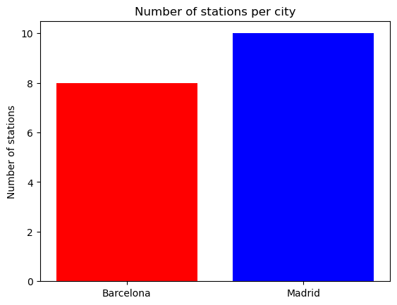

```python
stations_per_city = df_madrid_barcelona.groupby('City').count()['Name']
fig, ax = plt.subplots()
ax.bar(stations_per_city.index, stations_per_city.values, color=['red', 'blue'])
ax.set_ylabel('Number of stations')
ax.set_title('Number of stations per city')
plt.show()
```

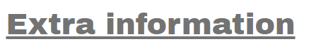

## - Countries Infromation

In this step we are going to load the `.csv`, followed by cleaning the **'Country'** column using the `.strip()` method, since it has spaces and strange symbols. This `.csv` contains a lot of information that we are not going to use, so we are going to save only the desired columns (**'Country', 'Region' and 'Population'**).

```python
countries = pd.read_csv('countries1.csv', encoding='utf-8')
countries['Country'] = countries['Country'].str.strip()
df_countries = countries[['Country', 'Region', 'Population']]
df_countries
```

|  | Country | Region | Population |
| --- | --- | --- | --- |
| 0 | Afghanistan | ASIA (EX. NEAR EAST) | 31056997 |
| 1 | Albania | EASTERN EUROPE | 3581655 |
| 2 | Algeria | NORTHERN AFRICA | 32930091 |
| 3 | American Samoa | OCEANIA | 57794 |
| 4 | Andorra | WESTERN EUROPE | 71201 |
| ... | ... | ... | ... |
| 222 | West Bank | NEAR EAST | 2460492 |
| 223 | Western Sahara | NORTHERN AFRICA | 273008 |
| 224 | Yemen | NEAR EAST | 21456188 |
| 225 | Zambia | SUB-SAHARAN AFRICA | 11502010 |
| 226 | Zimbabwe | SUB-SAHARAN AFRICA | 12236805 |

227 rows × 3 columns

### - Load the original DF of Airports

We bring the **Df** of airports that we used in the first part of the project. To this we filter all the airports in the column **'Type'** using the method `.loc` . We group all the cities of the same country and add them using the method `.groupby()`. We define the desired columns and finally we sort from highest to lowest according to the number of airports using the `sort_values()` method.

```python
df_only_airports = df_airports_v3.loc[df_airports_v3['Type'] == 'airport'].copy()
airports_by_country = df_only_airports.groupby('Country')['Name'].count().reset_index().copy()
airports_by_country.columns = ['Country', 'Airports']
airports_by_country.sort_values('Airports', ascending = False, inplace=True)
airports_by_country
```

|  | Country | Airports |
| --- | --- | --- |
| 223 | United States | 1752 |
| 37 | Canada | 459 |
| 11 | Australia | 343 |
| 176 | Russia | 271 |
| 27 | Brazil | 269 |
| ... | ... | ... |
| 17 | Barbados | 1 |
| 77 | Gambia | 1 |
| 156 | Niue | 1 |
| 45 | Cocos (Keeling) Islands | 1 |
| 102 | Isle of Man | 1 |

237 rows × 2 columns

### - We join the Df of the countries with the Df of the airports.

To join both **Df** we use the method `.merge()` and we tell it as a parameter to join both tables in the column **'Country'**.

```python
airports_countries = pd.merge(airports_by_country, df_countries, on='Country')
airports_countries
```

|  | Country | Airports | Region | Population |
| --- | --- | --- | --- | --- |
| 0 | United States | 1752 | NORTHERN AMERICA | 298444215 |
| 1 | Canada | 459 | NORTHERN AMERICA | 33098932 |
| 2 | Australia | 343 | OCEANIA | 20264082 |
| 3 | Russia | 271 | C.W. OF IND. STATES | 142893540 |
| 4 | Brazil | 269 | LATIN AMER. & CARIB | 188078227 |
| ... | ... | ... | ... | ... |
| 200 | Palau | 1 | OCEANIA | 20579 |
| 201 | Bermuda | 1 | NORTHERN AMERICA | 65773 |
| 202 | Tuvalu | 1 | OCEANIA | 11810 |
| 203 | Barbados | 1 | LATIN AMER. & CARIB | 279912 |
| 204 | Isle of Man | 1 | WESTERN EUROPE | 75441 |

205 rows × 4 columns

### - Showing the top 10 of the most populated countries

```python
top10 = airports_countries.sort_values('Population', ascending = False).head(10).copy()
top10
```

|  | Country | Airports | Region | Population |
| --- | --- | --- | --- | --- |
| 6 | China | 251 | ASIA (EX. NEAR EAST) | 1313973713 |
| 10 | India | 153 | ASIA (EX. NEAR EAST) | 1095351995 |
| 0 | United States | 1752 | NORTHERN AMERICA | 298444215 |
| 9 | Indonesia | 158 | ASIA (EX. NEAR EAST) | 245452739 |
| 4 | Brazil | 269 | LATIN AMER. & CARIB | 188078227 |
| 28 | Pakistan | 54 | ASIA (EX. NEAR EAST) | 165803560 |
| 95 | Bangladesh | 13 | ASIA (EX. NEAR EAST) | 147365352 |
| 3 | Russia | 271 | C.W. OF IND. STATES | 142893540 |
| 49 | Nigeria | 31 | SUB-SAHARAN AFRICA | 131859731 |
| 11 | Japan | 131 | ASIA (EX. NEAR EAST) | 127463611 |

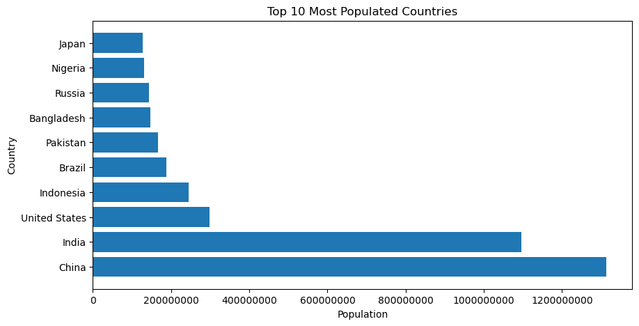

```python
fig, ax = plt.subplots(figsize=(10, 5))
ax.barh(top10['Country'], top10['Population'])
ax.set_xlabel('Population')
ax.set_ylabel('Country')
ax.set_title('Top 10 Most Populated Countries')
ax.ticklabel_format(useOffset=False, style='plain', axis='x')
plt.show()
```

### - The top 10 countries with the largest number of airports are shown below

```python
top10_airports = airports_countries.sort_values('Airports', ascending = False).head(10).copy()
top10_airports
```

|  | Country | Airports | Region | Population |
| --- | --- | --- | --- | --- |
| 0 | United States | 1752 | NORTHERN AMERICA | 298444215 |
| 1 | Canada | 459 | NORTHERN AMERICA | 33098932 |
| 2 | Australia | 343 | OCEANIA | 20264082 |
| 3 | Russia | 271 | C.W. OF IND. STATES | 142893540 |
| 4 | Brazil | 269 | LATIN AMER. & CARIB | 188078227 |
| 5 | Germany | 257 | WESTERN EUROPE | 82422299 |
| 6 | China | 251 | ASIA (EX. NEAR EAST) | 1313973713 |
| 7 | France | 221 | WESTERN EUROPE | 60876136 |
| 8 | United Kingdom | 177 | WESTERN EUROPE | 60609153 |
| 9 | Indonesia | 158 | ASIA (EX. NEAR EAST) | 245452739 |

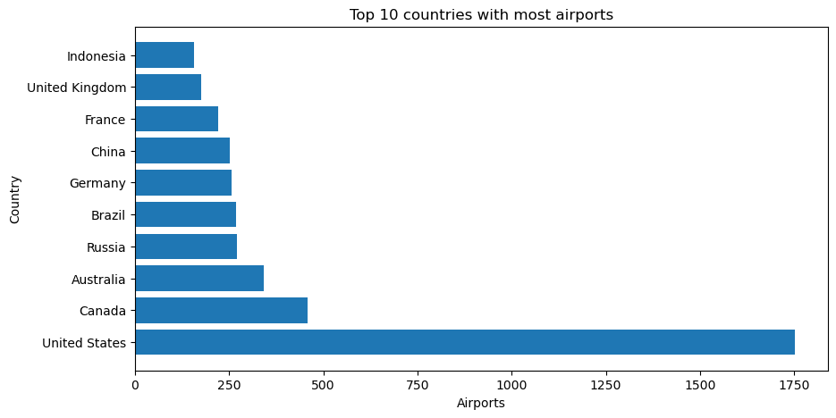

```python
fig, ax = plt.subplots(figsize=(10, 5))
ax.barh(top10_airports['Country'], top10_airports['Airports'])
ax.set_xlabel('Airports')
ax.set_ylabel('Country')
ax.set_title('Top 10 countries with most airports')
ax.ticklabel_format(useOffset=False, style='plain', axis='x')
plt.show()
```

### - Relationship between population and airports

Let's see if there is any correlation between population and number of airports, also taking the top 10 most populated countries.

[figure not shown]

```python
#We divide the number of airports by the population
top10_population = top10['Population']
top10_airports = top10['Airports']
country = top10['Country']
percentage = top10['Population'] / top10['Airports']

fig, ax = plt.subplots()

#We plot the relationship
ax.bar(country, top10_1, color = 'green')

ax.set_xlabel('Countries')
ax.set_ylabel('Airports per capita')
ax.set_title('Ratio of airports to population in the 10 most populous countries')

plt.xticks(rotation=90)
ax.ticklabel_format(useOffset=False, style='plain', axis='y')

plt.show()
```

We can see in the above graph that there is no direct relationship between the number of inhabitants and the number of airports. Since China is the most populated country in our list and has less airports than the USA, which is located in the number 3 position of the most populated countries. In conclusion, there is no relationship whatsoever.

## - Conclusions

With this analysis I'am reach the conclusion that there is no relation between the number of inhabitants and the number of countries. Maybe there is a relation with the income per person, tourist zones or international connections. Due to the lack of databases and information I have not been able to draw that conclusion, I have been searching the internet for different types of databases with extra information but I have not been able to find the correct one.

### - Bibliography

[Airport database - https://openflights.org/data.html](https://openflights.org/data.html)

[Countries database](https://github.com/HiraMariam/countries-data-for-pandas/blob/master/countries.csv)

[Information support with MatPlotlib and Pandas - https://www.freecodecamp.org/](https://www.freecodecamp.org/)